# PM_GWP2

```python
import yfinance as yf
import numpy as np
import pandas as pd
import matplotlib.pyplot as plt
import seaborn as sns
```

## **Step 1:**

```python
tickers = ['AAPL', 'META', 'GOOGL', 'AMZN','XOM']
start_date = '2021-01-01'
end_date = '2024-01-01'
data = yf.download(tickers, start_date, end_date)['Adj Close']
print(data.shape)
data.sample(5)
```

```
[*********************100%%**********************]  5 of 5 completed
```

```
(753, 5)
```

| Ticker Date | AAPL | AMZN | GOOGL | META | XOM |
| --- | --- | --- | --- | --- | --- |
| 2022-03-25 | 172.745926 | 164.773499 | 141.673004 | 221.820007 | 79.384239 |
| 2021-10-14 | 141.747955 | 164.992996 | 141.151001 | 328.529999 | 56.376831 |
| 2022-08-04 | 164.177460 | 142.570007 | 118.190002 | 170.570007 | 82.070564 |
| 2022-02-28 | 163.254364 | 153.563004 | 135.057007 | 211.029999 | 73.067039 |
| 2022-11-07 | 137.971756 | 90.529999 | 88.489998 | 96.720001 | 108.006844 |

```python
len(data)
```

```
753
```

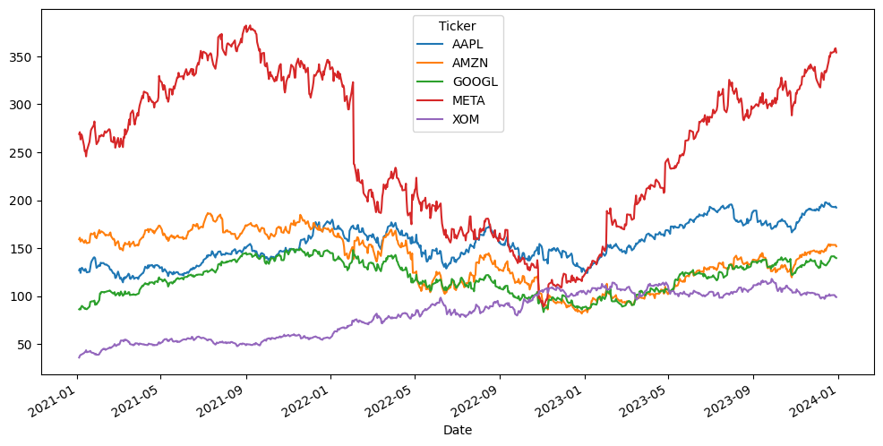

```python
fig, ax = plt.subplots(figsize=(12, 6))
data.plot(ax = ax)
```

```python
# Calculating daily returns
returns = np.log(data/data.shift(1))
returns.dropna(inplace=True)
returns.sample(5)
```

| Ticker Date | AAPL | AMZN | GOOGL | META | XOM |
| --- | --- | --- | --- | --- | --- |
| 2023-06-02 | 0.004764 | 0.011983 | 0.007649 | 0.000000 | 0.022954 |
| 2021-01-07 | 0.033554 | 0.007549 | 0.029431 | 0.020412 | 0.007815 |
| 2023-04-20 | -0.005863 | -0.004709 | 0.010598 | -0.012268 | -0.008010 |
| 2022-10-24 | 0.014694 | 0.004182 | 0.013651 | -0.002233 | 0.006966 |
| 2023-09-19 | 0.006162 | -0.016931 | -0.001231 | 0.008295 | -0.002639 |

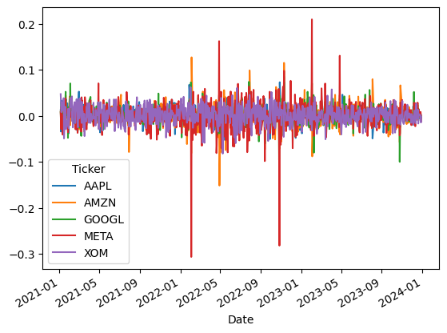

```python
returns.plot()
```

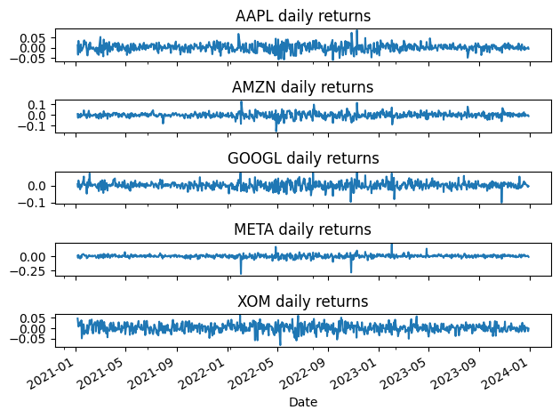

```python
# Visualizing Daily returns
fig, ax = plt.subplots(nrows=returns.shape[1])
for i, j in enumerate(returns):
    returns[j].plot(ax=ax[i], title=f'{j} daily returns')
    ax[i].sharex(ax[0])
fig.tight_layout()
```

```python
# Calculating covariance matrix
cov_matrix = returns.cov()
print('Covariance Matrix:\n', cov_matrix)

# Calculating correlation matrix
corr_matrix = returns.corr()
print('\nCorrelation Matrix:\n', corr_matrix)
```

```
Covariance Matrix:
 Ticker      AAPL      AMZN     GOOGL      META       XOM
Ticker
AAPL    0.000306  0.000251  0.000233  0.000287  0.000059
AMZN    0.000251  0.000556  0.000313  0.000417  0.000055
GOOGL   0.000233  0.000313  0.000400  0.000381  0.000056
META    0.000287  0.000417  0.000381  0.000916  0.000033
XOM     0.000059  0.000055  0.000056  0.000033  0.000362

Correlation Matrix:
 Ticker      AAPL      AMZN     GOOGL      META       XOM
Ticker
AAPL    1.000000  0.609018  0.665588  0.542249  0.175999
AMZN    0.609018  1.000000  0.664907  0.584981  0.123008
GOOGL   0.665588  0.664907  1.000000  0.628817  0.146408
META    0.542249  0.584981  0.628817  1.000000  0.057827
XOM     0.175999  0.123008  0.146408  0.057827  1.000000
```

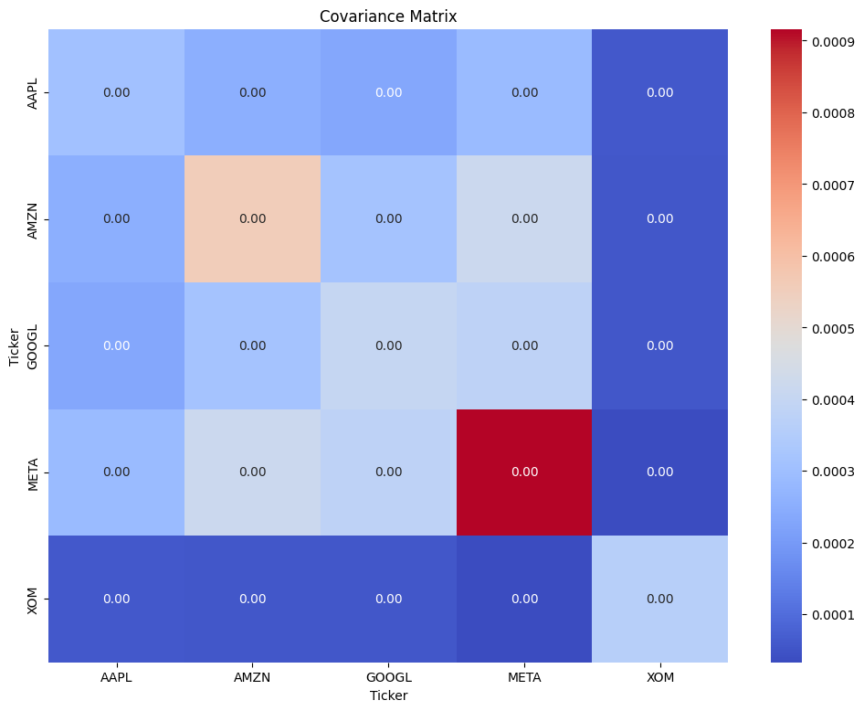

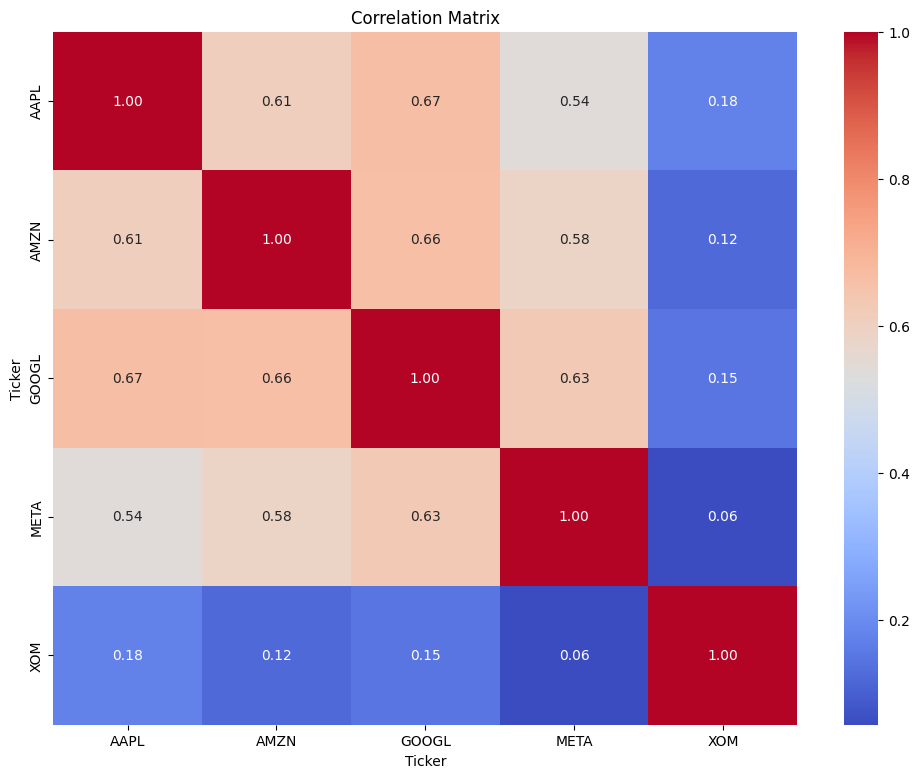

```python
# Visualizing Covariance Matrix
fig, ax = plt.subplots(figsize=(12, 9))
sns.heatmap(cov_matrix, annot=True, fmt=".2f", ax=ax, cmap="coolwarm")
ax.set_title('Covariance Matrix')
plt.show()

# Visualizing Correlation Matrix
fig, ax = plt.subplots(figsize=(12, 9))
sns.heatmap(corr_matrix, annot=True, fmt=".2f", ax=ax, cmap="coolwarm")
ax.set_title('Correlation Matrix')
plt.show()
```

## **Step 2:**

```python
def objective(weights, returns):
    # Calculate portfolio return
    portfolio_return = np.sum(returns.mean() * weights) * 252

    # Calculate portfolio variance
    portfolio_variance = np.sqrt(np.dot(weights.T, np.dot(returns.cov() * 252, weights)))

    # Return negative Sharpe ratio (minimize negative Sharpe ratio is equivalent to maximizing Sharpe ratio)
    return -portfolio_return / portfolio_variance
```

```python
# Define constraint: sum of weights equals one
def constraint(weights):
    return np.sum(weights) - 1
# Initial guess of equal weights
init_guess = np.array([1 / len(returns.columns)] * len(returns.columns))

# Define optimization bounds (weights between 0 and 1)
bounds = ((0, 1),) * len(returns.columns)
```

```python
from scipy.optimize import minimize
# Perform optimization
result = minimize(objective, init_guess, args=(returns,), method='SLSQP', constraints={'type': 'eq', 'fun': constraint}, bounds=bounds)

# Extract optimized weights
optimized_weights = result.x

# Display optimized weights
print("Optimized Weights:")
for i, ticker in enumerate(returns.columns):
    print(f"{ticker}: {optimized_weights[i]}")
```

```
Optimized Weights:
AAPL: 0.1054674933255629
AMZN: 0.0
GOOGL: 0.16865708937842094
META: 8.939246912142984e-17
XOM: 0.7258754172960162
```

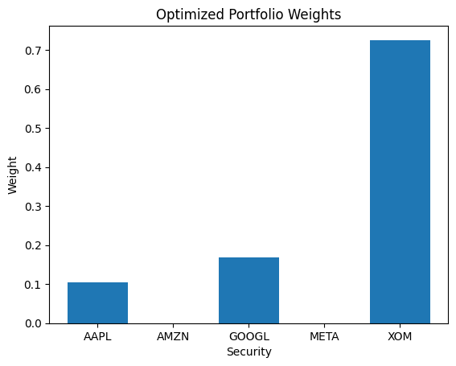

```python
# Visualize optimized weights
#plt.figure(figsize=(10, 6))
plt.bar(returns.columns, optimized_weights)
plt.xlabel('Security')
plt.ylabel('Weight')
plt.title('Optimized Portfolio Weights')
plt.show()
```

## **For Step 3:**

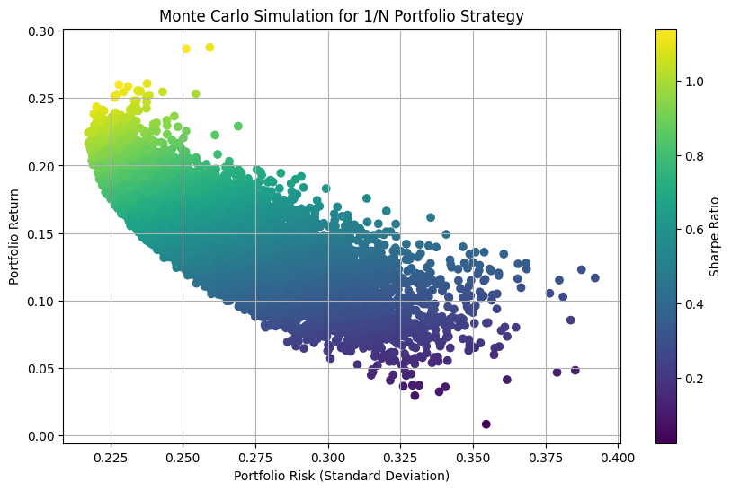

```python
# Monte Carlo Simulation
n_simulations = 10000
n_assets = len(tickers)

# Initialize arrays to store portfolio returns and risks
portfolio_returns = np.zeros(n_simulations)
portfolio_risks = np.zeros(n_simulations)

for i in range(n_simulations):
    # Generate random weights
    weights = np.random.rand(n_assets)
    weights /= np.sum(weights)  # Ensure weights sum up to 1

    # Calculate portfolio return and risk
    portfolio_return = np.sum(returns.mean() * weights) * 252
    portfolio_risk = np.sqrt(np.dot(weights.T, np.dot(returns.cov() * 252, weights)))

    # Store portfolio return and risk
    portfolio_returns[i] = portfolio_return
    portfolio_risks[i] = portfolio_risk

# Plot the results
plt.figure(figsize=(10, 6))
plt.scatter(portfolio_risks, portfolio_returns, c=portfolio_returns / portfolio_risks, marker='o', cmap='viridis')
plt.title('Monte Carlo Simulation for 1/N Portfolio Strategy')
plt.xlabel('Portfolio Risk (Standard Deviation)')
plt.ylabel('Portfolio Return')
plt.colorbar(label='Sharpe Ratio')
plt.grid(True)
plt.show()
```

### **Historical back-testing using a basic 1/N portfolio strategy. This strategy involves equally allocating the investment across all assets in the portfolio.**

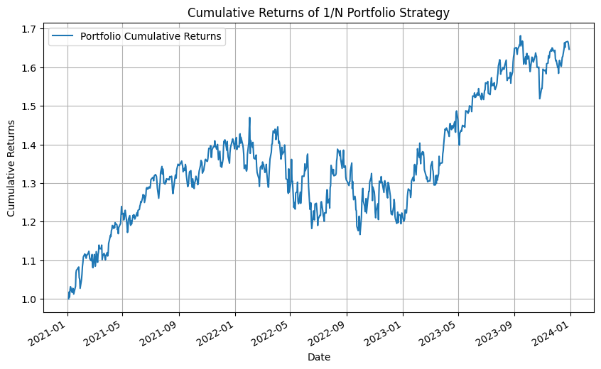

```python
# Define initial investment amount
initial_investment = 5000

# Calculate the number of shares for each asset (1/N portfolio strategy)
num_assets = len(tickers)
investment_per_asset = initial_investment / num_assets
num_shares = (investment_per_asset / data.iloc[0]).astype(int)

# Calculate the portfolio value over time
portfolio_value = (num_shares * data).sum(axis=1)
portfolio_returns = portfolio_value.pct_change().fillna(0)

# Calculate cumulative returns
cumulative_returns = (portfolio_returns + 1).cumprod()

# Plot cumulative returns
plt.figure(figsize=(10, 6))
cumulative_returns.plot(label='Portfolio Cumulative Returns')
plt.title('Cumulative Returns of 1/N Portfolio Strategy')
plt.xlabel('Date')
plt.ylabel('Cumulative Returns')
plt.grid(True)
plt.legend()
plt.show()
```

### **Let's consider a different approach to historical back-testing, focusing on a Monte Carlo simulation to generate various scenarios and evaluate portfolio performance.**

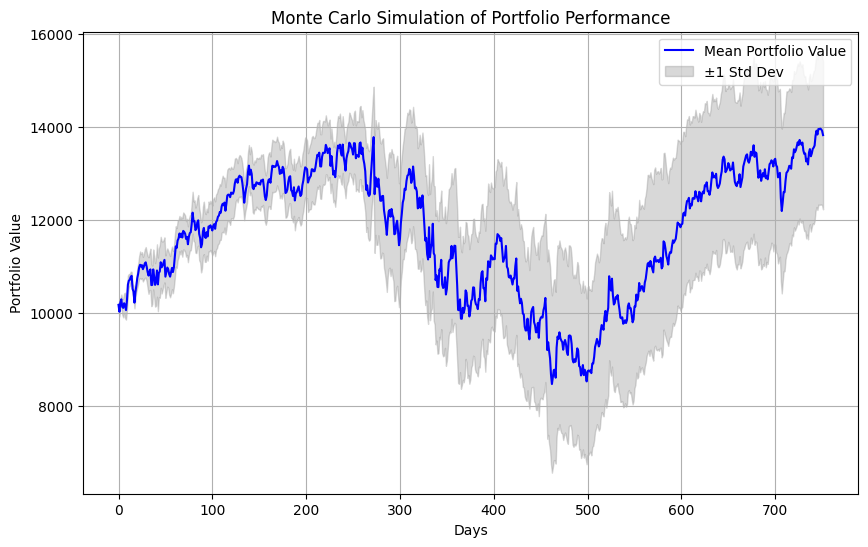

```python
# Define parameters for the Monte Carlo simulation
n_simulations = 5000
n_days = len(returns)

# Initialize an array to store portfolio values for each simulation
portfolio_values = np.zeros((n_simulations, n_days))

# Define initial investment amount
initial_investment = 10000

# Perform Monte Carlo simulation
for i in range(n_simulations):
    # Generate random weights for the portfolio
    weights = np.random.random(len(tickers))
    weights /= np.sum(weights)  # Normalize weights to sum up to 1

    # Calculate the portfolio value for each day
    portfolio_value = initial_investment
    for j in range(n_days):
        daily_returns = returns.iloc[j]
        portfolio_value *= 1 + np.dot(weights, daily_returns)
        portfolio_values[i, j] = portfolio_value

# Calculate mean and standard deviation of portfolio values for each day
mean_portfolio_values = np.mean(portfolio_values, axis=0)
std_portfolio_values = np.std(portfolio_values, axis=0)

# Plot the mean portfolio value and one standard deviation band
plt.figure(figsize=(10, 6))
plt.plot(mean_portfolio_values, color='blue', label='Mean Portfolio Value')
plt.fill_between(range(n_days), mean_portfolio_values - std_portfolio_values, mean_portfolio_values + std_portfolio_values, color='gray', alpha=0.3, label='±1 Std Dev')
plt.xlabel('Days')
plt.ylabel('Portfolio Value')
plt.title('Monte Carlo Simulation of Portfolio Performance')
plt.legend()
plt.grid(True)
plt.show()
```

### **Implementing historical back-testing using a simple buy-and-hold strategy for each asset in the portfolio**

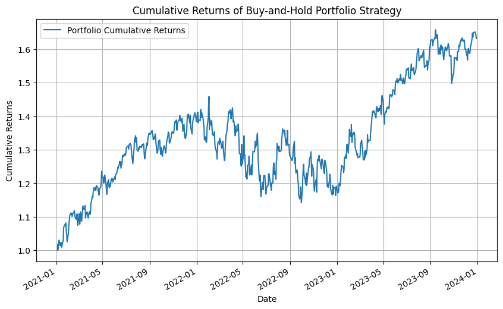

```python
# Define initial investment amount
initial_investment = 10000

# Calculate the number of shares for each asset (buy-and-hold strategy)
initial_prices = data.iloc[0]
num_shares = (initial_investment / initial_prices).astype(int)

# Calculate the portfolio value over time
portfolio_value = (num_shares * data).sum(axis=1)
portfolio_returns = portfolio_value.pct_change().fillna(0)

# Calculate cumulative returns
cumulative_returns = (portfolio_returns + 1).cumprod()

# Plot cumulative returns
plt.figure(figsize=(10, 6))
cumulative_returns.plot(label='Portfolio Cumulative Returns')
plt.title('Cumulative Returns of Buy-and-Hold Portfolio Strategy')
plt.xlabel('Date')
plt.ylabel('Cumulative Returns')
plt.grid(True)
plt.legend()
plt.show()
```

# Step 5: Black Litterman

The Black-Litterman portfolio optimization employs a Bayesian methodology to merge investor perspectives with the market's equilibrium expected return vector (known as the prior distribution), resulting in a blended forecast of expected returns.

```python
!pip install PyPortfolioOpt
```

```
     ━━━━━━━━━━━━━━━━━━━━━━━━━━━━━━━━━━━━━━━━ 61.9/61.9 kB 2.2 MB/s eta 0:00:00
```

```python
tickers = ['AAPL', 'META', 'GOOGL', 'AMZN', 'XOM']
start_date = '2021-01-01'
end_date = '2024-01-01'
prices = yf.download(tickers, start_date, end_date)['Adj Close']
print(prices.shape)
prices.sample(5)
```

```
[*********************100%%**********************]  5 of 5 completed
```

```
(753, 5)
```

| Ticker Date | AAPL | AMZN | GOOGL | META | XOM |
| --- | --- | --- | --- | --- | --- |
| 2023-06-22 | 186.264435 | 130.149994 | 123.150002 | 284.880005 | 100.596741 |
| 2022-10-24 | 148.184067 | 119.820000 | 102.519997 | 129.720001 | 101.315819 |
| 2023-01-19 | 134.346680 | 93.680000 | 93.050003 | 136.149994 | 106.653580 |
| 2023-04-18 | 165.586151 | 102.300003 | 104.500000 | 217.889999 | 112.900124 |
| 2022-08-31 | 155.888260 | 126.769997 | 108.220001 | 162.929993 | 90.851593 |

## Market-caps of our stocks to obtain the weights of the portfolio

```python
mcaps = {}
for t in tickers:
    stock = yf.Ticker(t)
    mcaps[t] = stock.info["marketCap"]
mcaps
```

```
{'AAPL': 2803631128576,
 'META': 1202684166144,
 'GOOGL': 1761600995328,
 'AMZN': 1735526711296,
 'XOM': 408020254720}
```

```python
market_prices = yf.download("^GSPC", start_date, end_date)["Adj Close"]
market_prices.head()
```

```
[*********************100%%**********************]  1 of 1 completed
```

```
Date
2021-01-04    3700.649902
2021-01-05    3726.860107
2021-01-06    3748.139893
2021-01-07    3803.790039
2021-01-08    3824.679932
Name: Adj Close, dtype: float64
```

```python
from pypfopt import black_litterman, risk_models
from pypfopt import BlackLittermanModel, plotting
cov_mat = risk_models.CovarianceShrinkage(prices).ledoit_wolf()
d = black_litterman.market_implied_risk_aversion(market_prices)
d
```

```
2.6017271118952525
```

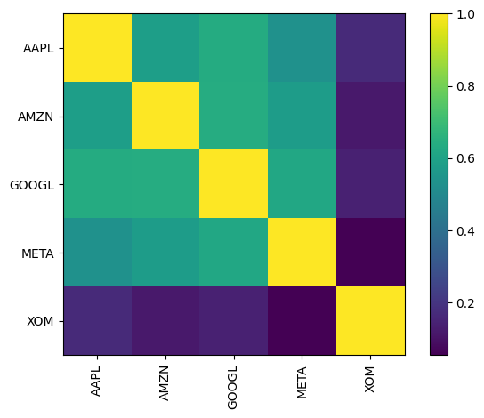

```python
plotting.plot_covariance(cov_mat, plot_correlation=True);
```

# Imblied Equilibrum excess returns

Market implied equilibrum excess return is calculated using the following formula. $$\Pi = \delta \Sigma \omega_{mkt}$$ where $\delta$ is market implied risk premium and given by $$\delta = \frac{R -R_f}{\sigma^2}$$ $R- R_f$ is excess return and $\sigma^2$ is variance, $\omega_{mkt}$ is the market-cap weights, and $\Sigma$ is variance covariance matrix.

```python
implied_equilibrum_ret = black_litterman.market_implied_prior_returns(mcaps, d, cov_mat)
implied_equilibrum_ret
```

```
Ticker
AAPL     0.189979
AMZN     0.241678
GOOGL    0.213159
META     0.283341
XOM      0.064174
dtype: float64
```

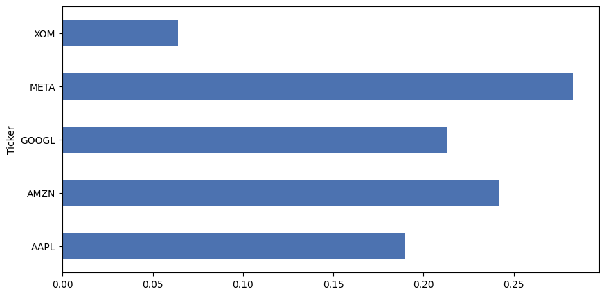

```python
implied_equilibrum_ret.plot.barh(figsize=(10,5));
```

# Views on the portfolio assets

# Apple

On February 1, 2024, Apple unveiled its financial outcomes for the initial quarter of the fiscal year 2024, concluding on December 30, 2023. The company disclosed quarterly revenue amounting to \$111.6 billion, alongside a quarterly earnings per share of \$2.18. As of February 2024, Apple's beta stands at 1.13. Given this data, we project a 10% absolute growth in Apple's stock.

# Google

Google has been making significant strides in Artificial Intelligence (AI) and Machine Learning (ML), with 2024 poised to witness further groundbreaking advancements. These innovations are reshaping the landscape of search and digital marketing. Google reported revenue of \$86.31 billion and earnings per share of \$1.64. As of February 2024, Google's beta is at 1.06. Consequently, we foresee a 12% rise in GOOGLE's trajectory.

# META

Mark Zuckerberg's announcement on December 14, 2023, regarding the expansion of Threads into European markets is significant. Moreover, the potential inclusion of 448 million users to Instagram's reach in Europe underscores the importance of broadening Threads' accessibility. META remains actively involved in the metaverse domain, with promising prospects for leveraging generative AI. With a beta of 1.16, we hold the view that META will outperform AMZN by 5%.

# Exxon Mobil Corporation (XOM)

Exxon Mobil Corporation (XOM) reported an annual EPS of \$2.48 for 2023, excluding some items. This was higher than the Zacks Consensus Estimate of \$2.21, but lower than the previous year's EPS of \$3.40. The company's revenue for the fourth quarter of 2023 was \$84,344 million, which was a decrease from the \$95,429 million revenue of the same quarter in 2022. XOM's beta as of February 2024 was 0.97, indicating that the stock was slightly less volatile than the market. According to the ExxonMobil announces 2023 results report, XOM delivered a profit of \$36 billion in 2023. This was the company’s second-highest annual profit in a decade, despite the challenging energy landscape and lower oil prices. The company has also made strategic moves to enhance its portfolio, such as divesting its non-core assets, investing in low-carbon technologies, and expanding its presence in the Permian Basin. Therefore, we anticipate an 8\% increase in Exxon Mobil's returns.

```python
view_dict ={"AAPL": 0.1,
           "META": 0.05,
           "GOOGL": 0.12,
           "XOM": 0.08}
Q = np.array([0.1, 0.05, 0.12, 0.08])
P = np.array([[1, 0, 0,  0,  0],
              [0, -1 ,0, 1,  0],
              [0, 0, 1,  0,  0],
              [0, 0, 0,  0,  1],
             ])
Omega = BlackLittermanModel.default_omega(cov_matrix = cov_mat, P = P, tau = 0.05)
Omega
```

```
array([[0.0039316 , 0.        , 0.        , 0.        ],
       [0.        , 0.00782593, 0.        , 0.        ],
       [0.        , 0.        , 0.00506819, 0.        ],
       [0.        , 0.        , 0.        , 0.00460635]])
```

```python
bl = BlackLittermanModel(cov_mat, pi=implied_equilibrum_ret, P = P, Q = Q, omega = Omega)
```

```python
# Posterior estimate of returns
ret_bl = bl.bl_returns()
ret_bl
```

```
Ticker
AAPL     0.136534
AMZN     0.186675
GOOGL    0.154892
META     0.227196
XOM      0.066248
dtype: float64
```

```python
rets_df = pd.DataFrame([implied_equilibrum_ret, ret_bl, implied_equilibrum_ret-ret_bl, pd.Series(view_dict)],
             index=["Prior", "Posterior","Difference", "Views"]).T
rets_df
```

|  | Prior | Posterior | Difference | Views |
| --- | --- | --- | --- | --- |
| AAPL | 0.189979 | 0.136534 | 0.053445 | 0.10 |
| AMZN | 0.241678 | 0.186675 | 0.055003 | NaN |
| GOOGL | 0.213159 | 0.154892 | 0.058266 | 0.12 |
| META | 0.283341 | 0.227196 | 0.056145 | 0.05 |
| XOM | 0.064174 | 0.066248 | -0.002074 | 0.08 |

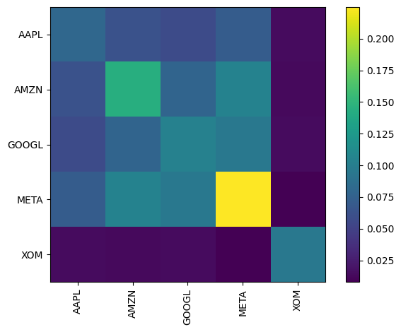

```python
cov_bl = bl.bl_cov()
plotting.plot_covariance(cov_bl);
```

```python
from pypfopt import EfficientFrontier, objective_functions
```

```python
ef = EfficientFrontier(ret_bl, cov_bl)
ef.add_objective(objective_functions.L2_reg)
ef.max_sharpe()
weights = ef.clean_weights()
weights
```

```
OrderedDict([('AAPL', 0.1761),
             ('AMZN', 0.24831),
             ('GOOGL', 0.19797),
             ('META', 0.30074),
             ('XOM', 0.07688)])
```

# Step 5

**1. Perform back-testing using the Kelly criterion for each security in the portfolio to size the allocation to that security.**

*APPLE*

```
[*********************100%%**********************]  5 of 5 completed
```

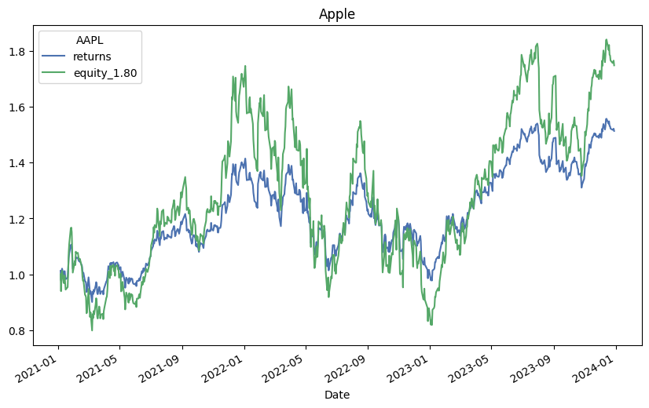

```python
import pandas as pd
import numpy as np
import math
import matplotlib.pyplot as plt

tickers = ['AAPL', 'META', 'GOOGL', 'AMZN','XOM']
start_date = '2021-01-01'
end_date = '2024-01-01'
data = yf.download(tickers, start_date, end_date)['Adj Close']

# Initialize equs
equs = []

data = data[['AAPL']]

def kelly_strategy(data, f):
    global equs # a list to store equity column names

    # Create column names for equity and capital based on the given fraction (f)
    equ = 'equity_{:.2f}'.format(f)
    equs.append(equ)
    cap = 'capital_{:.2f}'.format(f)

    # Initialize equity and capital columns with initial values
    data[equ] = 1
    data[cap] = data[equ] * f

    # Iterate over the index of the DataFrame (excluding the first element)
    for i, t in enumerate(data.index[1:]):
        t_1 = data.index[i]

        # Calculate the capital at time 't' based on the previous capital and return
        data.loc[t, cap] = data[cap].loc[t_1] * \
                            math.exp(data['returns'].loc[t])

        # Calculate the equity at time 't' based on the change in capital and previous equity
        data.loc[t, equ] = data[cap].loc[t] - \
                            data[cap].loc[t_1] + \
                            data[equ].loc[t_1]

        # Update the capital at time 't' to be the same as the equity scaled by the fraction (f)
        data.loc[t, cap] = data[equ].loc[t] * f

data['returns'] = np.log(data / data.shift(1))
data.dropna(inplace=True)

mu = data.returns.mean() * 252
sigma = data.returns.std() * 252 ** 0.5

r = 0.00  # Risk-free rate
f = (mu - r) / sigma ** 2

# Apply the Kelly strategy for fraction f
kelly_strategy(data, f)

# Plot cumulative returns and equity values
ax = data['returns'].cumsum().apply(np.exp).plot(legend=True, figsize=(10, 6))
data[equs].plot(ax=ax, legend=True)
plt.title('Apple')
plt.legend(title='AAPL')
plt.show()
```

*META*

```
[*********************100%%**********************]  5 of 5 completed
```

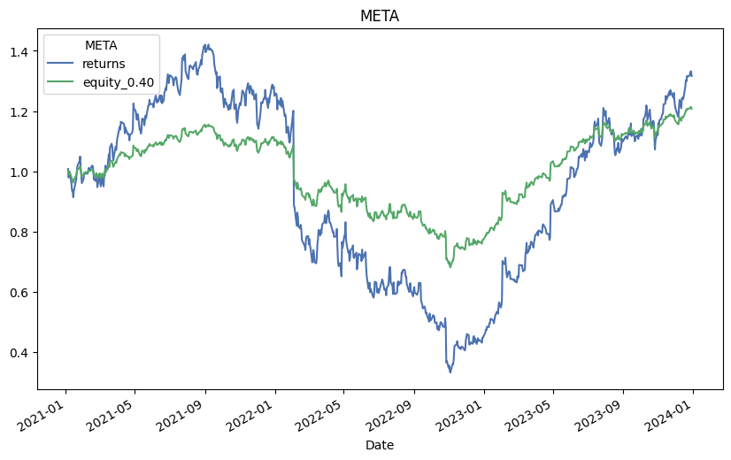

```python
tickers = ['AAPL', 'META', 'GOOGL', 'AMZN','XOM']
start_date = '2021-01-01'
end_date = '2024-01-01'
data = yf.download(tickers, start_date, end_date)['Adj Close']

# Initialize equs
equs = []

data = data[['META']]

def kelly_strategy(data, f):
    global equs # a list to store equity column names

    # Create column names for equity and capital based on the given fraction (f)
    equ = 'equity_{:.2f}'.format(f)
    equs.append(equ)
    cap = 'capital_{:.2f}'.format(f)

    # Initialize equity and capital columns with initial values
    data[equ] = 1
    data[cap] = data[equ] * f

    # Iterate over the index of the DataFrame (excluding the first element)
    for i, t in enumerate(data.index[1:]):
        t_1 = data.index[i]

        # Calculate the capital at time 't' based on the previous capital and return
        data.loc[t, cap] = data[cap].loc[t_1] * \
                            math.exp(data['returns'].loc[t])

        # Calculate the equity at time 't' based on the change in capital and previous equity
        data.loc[t, equ] = data[cap].loc[t] - \
                            data[cap].loc[t_1] + \
                            data[equ].loc[t_1]

        # Update the capital at time 't' to be the same as the equity scaled by the fraction (f)
        data.loc[t, cap] = data[equ].loc[t] * f

data['returns'] = np.log(data / data.shift(1))
data.dropna(inplace=True)

mu = data.returns.mean() * 252
sigma = data.returns.std() * 252 ** 0.5

r = 0.00  # Risk-free rate
f = (mu - r) / sigma ** 2

# Apply the Kelly strategy for fraction f
kelly_strategy(data, f)

# Plot cumulative returns and equity values
ax = data['returns'].cumsum().apply(np.exp).plot(legend=True, figsize=(10, 6))
data[equs].plot(ax=ax, legend=True)
plt.title('META')
plt.legend(title='META')
plt.show()
```

*GOOGLE*

```
[*********************100%%**********************]  5 of 5 completed
```

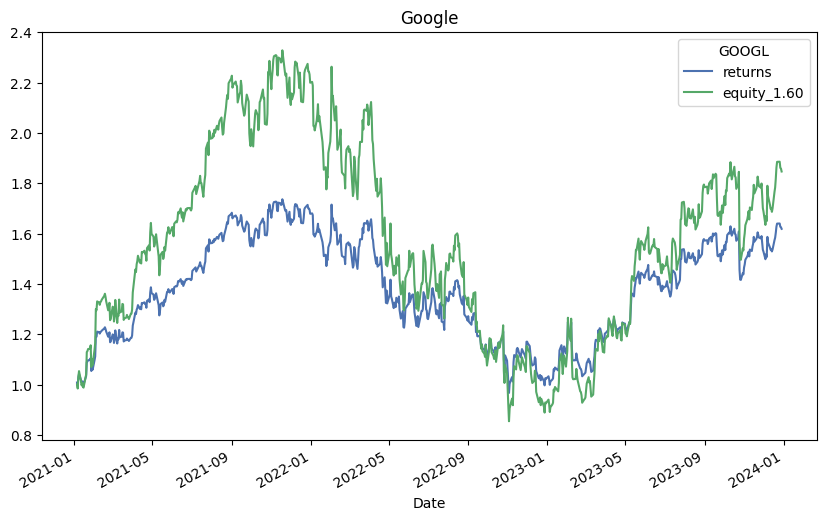

```python
tickers = ['AAPL', 'META', 'GOOGL', 'AMZN','XOM']
start_date = '2021-01-01'
end_date = '2024-01-01'
data = yf.download(tickers, start_date, end_date)['Adj Close']

# Initialize equs
equs = []

data = data[['GOOGL']]

def kelly_strategy(data, f):
    global equs # a list to store equity column names

    # Create column names for equity and capital based on the given fraction (f)
    equ = 'equity_{:.2f}'.format(f)
    equs.append(equ)
    cap = 'capital_{:.2f}'.format(f)

    # Initialize equity and capital columns with initial values
    data[equ] = 1
    data[cap] = data[equ] * f

    # Iterate over the index of the DataFrame (excluding the first element)
    for i, t in enumerate(data.index[1:]):
        t_1 = data.index[i]

        # Calculate the capital at time 't' based on the previous capital and return
        data.loc[t, cap] = data[cap].loc[t_1] * \
                            math.exp(data['returns'].loc[t])

        # Calculate the equity at time 't' based on the change in capital and previous equity
        data.loc[t, equ] = data[cap].loc[t] - \
                            data[cap].loc[t_1] + \
                            data[equ].loc[t_1]

        # Update the capital at time 't' to be the same as the equity scaled by the fraction (f)
        data.loc[t, cap] = data[equ].loc[t] * f

data['returns'] = np.log(data / data.shift(1))
data.dropna(inplace=True)

mu = data.returns.mean() * 252
sigma = data.returns.std() * 252 ** 0.5

r = 0.00  # Risk-free rate
f = (mu - r) / sigma ** 2

# Apply the Kelly strategy for fraction f
kelly_strategy(data, f)

# Plot cumulative returns and equity values
ax = data['returns'].cumsum().apply(np.exp).plot(legend=True, figsize=(10, 6))
data[equs].plot(ax=ax, legend=True)
plt.title('Google')
plt.legend(title='GOOGL')
plt.show()
```

*AMAZON*

```
[*********************100%%**********************]  5 of 5 completed
```

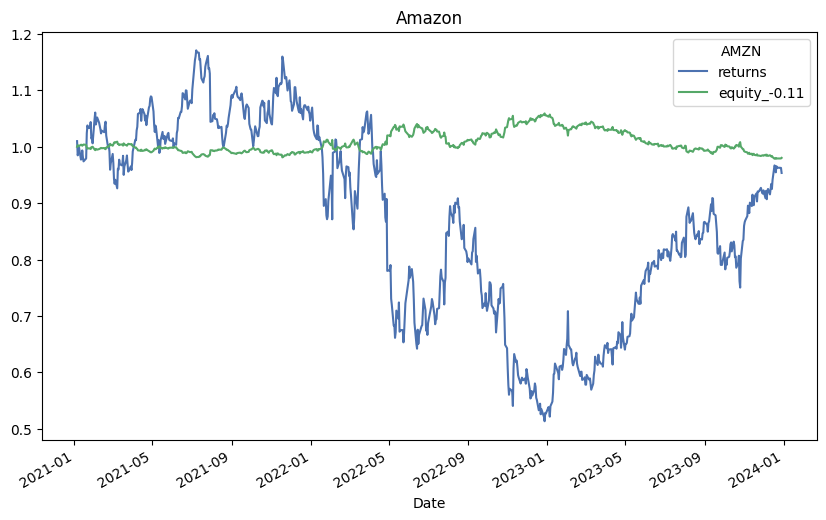

```python
tickers = ['AAPL', 'META', 'GOOGL', 'AMZN','XOM']
start_date = '2021-01-01'
end_date = '2024-01-01'
data = yf.download(tickers, start_date, end_date)['Adj Close']

# Initialize equs
equs = []

data = data[['AMZN']]

def kelly_strategy(data, f):
    global equs # a list to store equity column names

    # Create column names for equity and capital based on the given fraction (f)
    equ = 'equity_{:.2f}'.format(f)
    equs.append(equ)
    cap = 'capital_{:.2f}'.format(f)

    # Initialize equity and capital columns with initial values
    data[equ] = 1
    data[cap] = data[equ] * f

    # Iterate over the index of the DataFrame (excluding the first element)
    for i, t in enumerate(data.index[1:]):
        t_1 = data.index[i]

        # Calculate the capital at time 't' based on the previous capital and return
        data.loc[t, cap] = data[cap].loc[t_1] * \
                            math.exp(data['returns'].loc[t])

        # Calculate the equity at time 't' based on the change in capital and previous equity
        data.loc[t, equ] = data[cap].loc[t] - \
                            data[cap].loc[t_1] + \
                            data[equ].loc[t_1]

        # Update the capital at time 't' to be the same as the equity scaled by the fraction (f)
        data.loc[t, cap] = data[equ].loc[t] * f

data['returns'] = np.log(data / data.shift(1))
data.dropna(inplace=True)

mu = data.returns.mean() * 252
sigma = data.returns.std() * 252 ** 0.5

r = 0.00  # Risk-free rate
f = (mu - r) / sigma ** 2

# Apply the Kelly strategy for fraction f
kelly_strategy(data, f)

# Plot cumulative returns and equity values
ax = data['returns'].cumsum().apply(np.exp).plot(legend=True, figsize=(10, 6))
data[equs].plot(ax=ax, legend=True)
plt.title('Amazon')
plt.legend(title='AMZN')
plt.show()
```

*EXXON MOBIL*

[output not shown]

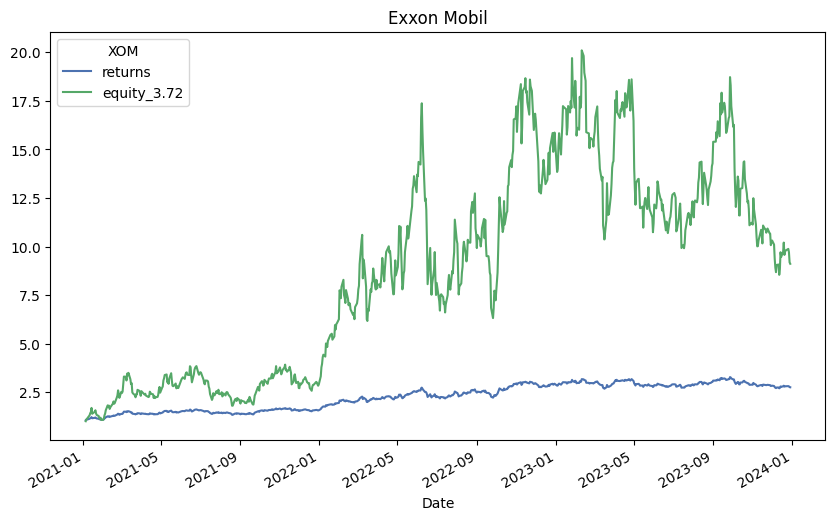

```python
tickers = ['AAPL', 'META', 'GOOGL', 'AMZN','XOM']
start_date = '2021-01-01'
end_date = '2024-01-01'
data = yf.download(tickers, start_date, end_date)['Adj Close']

# Initialize equs
equs = []

data = data[['XOM']]

def kelly_strategy(data, f):
    global equs # a list to store equity column names

    # Create column names for equity and capital based on the given fraction (f)
    equ = 'equity_{:.2f}'.format(f)
    equs.append(equ)
    cap = 'capital_{:.2f}'.format(f)

    # Initialize equity and capital columns with initial values
    data[equ] = 1
    data[cap] = data[equ] * f

    # Iterate over the index of the DataFrame (excluding the first element)
    for i, t in enumerate(data.index[1:]):
        t_1 = data.index[i]

        # Calculate the capital at time 't' based on the previous capital and return
        data.loc[t, cap] = data[cap].loc[t_1] * \
                            math.exp(data['returns'].loc[t])

        # Calculate the equity at time 't' based on the change in capital and previous equity
        data.loc[t, equ] = data[cap].loc[t] - \
                            data[cap].loc[t_1] + \
                            data[equ].loc[t_1]

        # Update the capital at time 't' to be the same as the equity scaled by the fraction (f)
        data.loc[t, cap] = data[equ].loc[t] * f

data['returns'] = np.log(data / data.shift(1))
data.dropna(inplace=True)

mu = data.returns.mean() * 252
sigma = data.returns.std() * 252 ** 0.5

r = 0.00  # Risk-free rate
f = (mu - r) / sigma ** 2

# Apply the Kelly strategy for fraction f
kelly_strategy(data, f)

# Plot cumulative returns and equity values
ax = data['returns'].cumsum().apply(np.exp).plot(legend=True, figsize=(10, 6))
data[equs].plot(ax=ax, legend=True)
plt.title('Exxon Mobil')
plt.legend(title='XOM')
plt.show()
```

**2. Perform a series of historical backtests to see how the combined portfolio performs.**

```python
import yfinance as yf
import numpy as np
import pandas as pd
import matplotlib.pyplot as plt

tickers = ['AAPL', 'META', 'GOOGL', 'AMZN','XOM']
start_date = '2021-01-01'
end_date = '2024-01-01'

data = yf.download(tickers, start_date, end_date)['Adj Close']

#  returns
returns = data.pct_change().dropna()

# Mean returns and standard dev
expected_returns = returns.mean()
risks = returns.std()

# Calculate Kelly Criterion fraction
rf = 0.0  # we assume a risk-free rate of 0
kelly_fraction = (expected_returns - rf) / risks**2

# Normalize Kelly fractions so the add up to 1
kelly_fraction /= kelly_fraction.sum()

# Print results
print("Kelly Criterion Fraction:")
print(kelly_fraction)

# Allocate capital according to Kelly Criterion
capital = 100000  # Starting capital
allocation = kelly_fraction * capital

# Print allocations
print("\nAllocation:")
print(allocation)
```

```
[*********************100%%**********************]  5 of 5 completed
```

```
Kelly Criterion Fraction:
Ticker
AAPL     0.231419
AMZN     0.038840
GOOGL    0.211657
META     0.093293
XOM      0.424792
dtype: float64

Allocation:
Ticker
AAPL     23141.891836
AMZN      3883.959870
GOOGL    21165.716586
META      9329.271690
XOM      42479.160018
dtype: float64
```

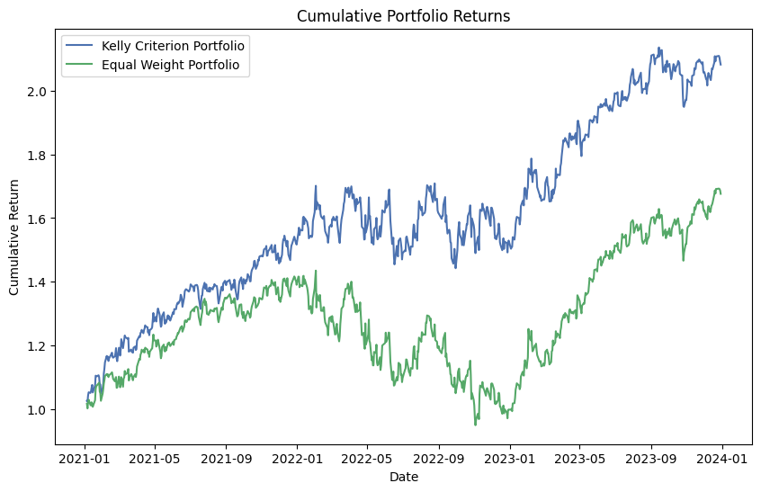

```
Final Portfolio Value (Kelly Criterion): $ 208173.74338117542
Final Portfolio Value (Equal Weights): $ 167616.1705914124
```

```python
# Comparing equal weight portfolio versus the Kelly Criterion portfolio

# Calculate equal weights
n_assets = len(tickers)
equal_weights = np.ones(n_assets) / n_assets

# Allocate capital equally
equal_allocation = equal_weights * capital

# Calculate the combined portfolio return for Kelly Criterion and equal weights
portfolio_return_kelly = (returns * kelly_fraction).sum(axis=1)
portfolio_return_equal = (returns * equal_weights).sum(axis=1)

# Calculate the cumulative portfolio return
cumulative_return_kelly = (1 + portfolio_return_kelly).cumprod()
cumulative_return_equal = (1 + portfolio_return_equal).cumprod()

# Plot the cumulative portfolio returns for comparison
plt.figure(figsize=(10, 6))
plt.plot(cumulative_return_kelly, label='Kelly Criterion Portfolio')
plt.plot(cumulative_return_equal, label='Equal Weight Portfolio')
plt.title('Cumulative Portfolio Returns')
plt.xlabel('Date')
plt.ylabel('Cumulative Return')
plt.legend()
plt.show()

# Calculate and print the final portfolio values
final_portfolio_value_kelly = capital * cumulative_return_kelly[-1]
final_portfolio_value_equal = capital * cumulative_return_equal[-1]
print("Final Portfolio Value (Kelly Criterion): $", final_portfolio_value_kelly)
print("Final Portfolio Value (Equal Weights): $", final_portfolio_value_equal)
```